# Bivariate analysis of enteric fever and leptospirosis

# Ripley’s K cross function

calculate K cross

```r
K16 <- Kcross(loc_list2016.ppp, "Leptospirosis", "Enteric_fever")
K17 <- Kcross(loc_list2017.ppp, "Leptospirosis", "Enteric_fever")
K18 <- Kcross(loc_list2018.ppp, "Leptospirosis", "Enteric_fever")
K19 <- Kcross(loc_list2019.ppp, "Leptospirosis", "Enteric_fever")
K20 <- Kcross(loc_list2020.ppp, "Leptospirosis", "Enteric_fever")
K21 <- Kcross(loc_list2021.ppp, "Leptospirosis", "Enteric_fever")
K22 <- Kcross(loc_list2022.ppp, "Leptospirosis", "Enteric_fever")
Kall <- Kcross(all_diag.ppp, "Leptospirosis", "Enteric_fever")
```

plot Ripley’s cross K function - Departures from the reference line indicate clustering of the two types of points relative to each other - When the observed K value is larger than the expected K value for a particular distance, the distribution is more clustered than a random distribution at that distance (scale of analysis). When the observed K value is smaller than the expected K value, the distribution is more dispersed than a random distribution at that distance

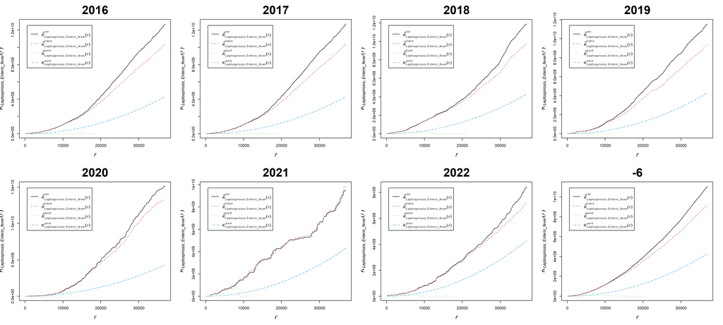

```r
par(mfrow=c(2,4))
plot(K16, main = 2016, cex.main = 3, cex.lab = 1.5)
plot(K17, main = 2017, cex.main = 3, cex.lab = 1.5)
plot(K18, main = 2018, cex.main = 3, cex.lab = 1.5)
plot(K19, main = 2019, cex.main = 3, cex.lab = 1.5)
plot(K20, main = 2020, cex.main = 3, cex.lab = 1.5)
plot(K21, main = 2021, cex.main = 3, cex.lab = 1.5)
plot(K22, main = 2022, cex.main = 3, cex.lab = 1.5)
plot(Kall, main = 2016-2022, cex.main = 3, cex.lab = 1.5)
```

# Kdot

Calculate Kdot

```r
Kdot16 <- Kdot(loc_list2016.ppp, "Leptospirosis")
Kdot17 <- Kdot(loc_list2017.ppp, "Leptospirosis")
Kdot18 <- Kdot(loc_list2018.ppp, "Leptospirosis")
Kdot19 <- Kdot(loc_list2019.ppp, "Leptospirosis")
Kdot20 <- Kdot(loc_list2020.ppp, "Leptospirosis")
Kdot21 <- Kdot(loc_list2021.ppp, "Leptospirosis")
Kdot22 <- Kdot(loc_list2022.ppp, "Leptospirosis")
Kdotall <- Kdot(all_diag.ppp, "Leptospirosis")
```

Plot Kdot - Departures from the reference line indicate clustering or repulsion of the leptospirosis points relative to others

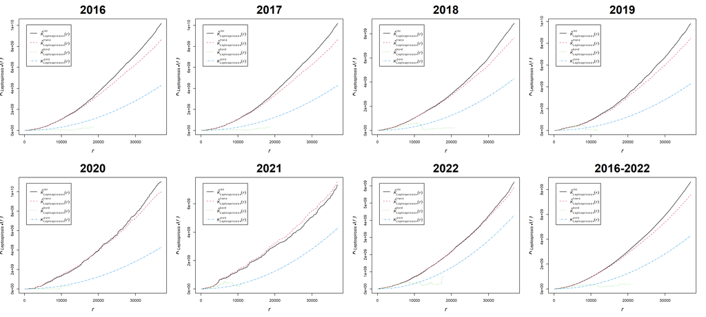

```r
par(mfrow=c(2,4))
plot(Kdot16, main = "2016", cex.main = 3, cex.lab = 1.5)
plot(Kdot17, main = "2017", cex.main = 3, cex.lab = 1.5)
plot(Kdot18, main = "2018", cex.main = 3, cex.lab = 1.5)
plot(Kdot19, main = "2019", cex.main = 3, cex.lab = 1.5)
plot(Kdot20, main = "2020", cex.main = 3, cex.lab = 1.5)
plot(Kdot21, main = "2021", cex.main = 3, cex.lab = 1.5)
plot(Kdot22, main = "2022", cex.main = 3, cex.lab = 1.5)
plot(Kdotall, main = "2016-2022", cex.main = 3, cex.lab = 1.5)
```

# Pair correlation function

pcf for K cross

```r
K16pcf<- pcf(K16, spar=1, method="b")
K17pcf<- pcf(K17, spar=1, method="b")
K18pcf<- pcf(K18, spar=1, method="b")
K19pcf<- pcf(K19, spar=1, method="b")
K20pcf<- pcf(K20, spar=1, method="b")
K21pcf<- pcf(K21, spar=1, method="b")
K22pcf<- pcf(K22, spar=1, method="b")
Kallpcf<- pcf(Kall, spar=1, method="b")
```

Plot pcf for K cross

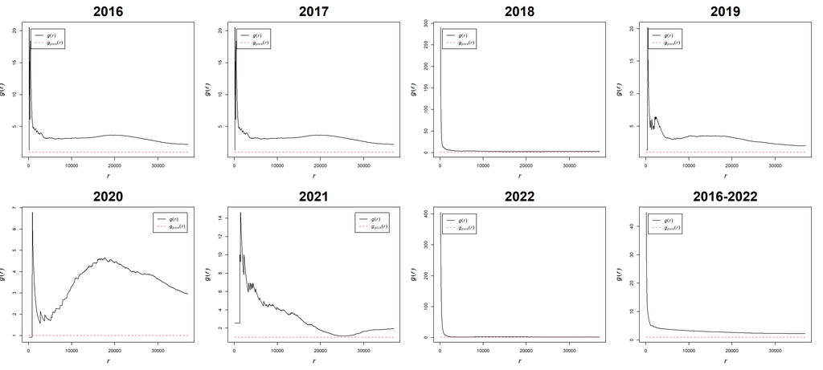

```r
par(mfrow=c(2,4))
plot(K16pcf, main = "2016", cex.main = 3, cex.lab = 1.5)
plot(K17pcf, main = "2017", cex.main = 3, cex.lab = 1.5)
plot(K18pcf, main = "2018", cex.main = 3, cex.lab = 1.5)
plot(K19pcf, main = "2019", cex.main = 3, cex.lab = 1.5)
plot(K20pcf, main = "2020", cex.main = 3, cex.lab = 1.5)
plot(K21pcf, main = "2021", cex.main = 3, cex.lab = 1.5)
plot(K22pcf, main = "2022", cex.main = 3, cex.lab = 1.5)
plot(Kallpcf, main = "2016-2022", cex.main = 3, cex.lab = 1.5)
```

```r
# pcf cross
cross16pcf <- pcfcross(loc_list2016.ppp, "Leptospirosis", "Enteric_fever", stoyan=0.1)
cross17pcf <- pcfcross(loc_list2017.ppp, "Leptospirosis", "Enteric_fever", stoyan=0.1)
cross18pcf <- pcfcross(loc_list2018.ppp, "Leptospirosis", "Enteric_fever", stoyan=0.1)
cross19pcf <- pcfcross(loc_list2019.ppp, "Leptospirosis", "Enteric_fever", stoyan=0.1)
cross20pcf <- pcfcross(loc_list2020.ppp, "Leptospirosis", "Enteric_fever", stoyan=0.1)
cross21pcf <- pcfcross(loc_list2021.ppp, "Leptospirosis", "Enteric_fever", stoyan=0.1)
cross22pcf <- pcfcross(loc_list2022.ppp, "Leptospirosis", "Enteric_fever", stoyan=0.1)
crosspcf <- pcfcross(all_diag.ppp, "Leptospirosis", "Enteric_fever", stoyan=0.1)
```

```r
crosspcf <- pcfcross(all_diag.ppp, "Leptospirosis", "Enteric_fever", stoyan=0.1)
```

plot cross pcf - A value g(r) < 1 indicates that interpoint distances equal to r are less frequent than would be expected for a completely random process, so this suggests regularity. A value g(r) > 1 indicates that this interpoint distance is more frequent than expected for a completely random pattern, which suggests clustering.

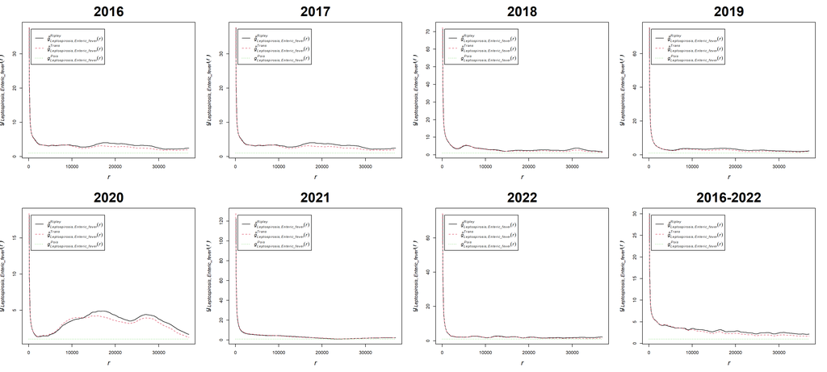

```r
par(mfrow=c(2,4))
plot(cross16pcf, main = "2016", cex.main = 3, cex.lab = 1.5)
plot(cross17pcf, main = "2017", cex.main = 3, cex.lab = 1.5)
plot(cross18pcf, main = "2018", cex.main = 3, cex.lab = 1.5)
plot(cross19pcf, main = "2019", cex.main = 3, cex.lab = 1.5)
plot(cross20pcf, main = "2020", cex.main = 3, cex.lab = 1.5)
plot(cross21pcf, main = "2021", cex.main = 3, cex.lab = 1.5)
plot(cross22pcf, main = "2022", cex.main = 3, cex.lab = 1.5)
plot(crosspcf, main = "2016-2022", cex.main = 3, cex.lab = 1.5)
```

enveloped ripley cross K - When the observed K value is larger than the upper confidence envelope (HiConfEnv) value, spatial clustering for that distance is statistically significant. When the observed K value is smaller than the lower confidence envelope (LwConfEnv) value, spatial dispersion for that distance is statistically significant.

[output not shown]

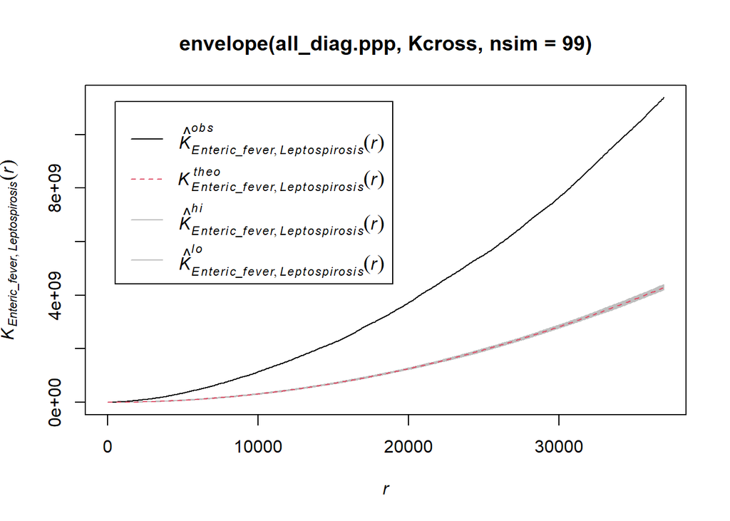

```r
env_K01 <- plot(envelope(all_diag.ppp, Kcross, nsim = 99))
```

```r
env_K16 <- envelope(loc_list2016.ppp, Kcross, nsim = 99)
```

[output not shown]

```r
env_K17 <- envelope(loc_list2017.ppp, Kcross, nsim = 99)
```

[output not shown]

```r
env_K18 <- envelope(loc_list2018.ppp, Kcross, nsim = 99)
```

[output not shown]

```r
env_K19 <- envelope(loc_list2019.ppp, Kcross, nsim = 99)
```

[output not shown]

```r
env_K20 <- envelope(loc_list2020.ppp, Kcross, nsim = 99)
```

[output not shown]

```r
env_K21 <- envelope(loc_list2021.ppp, Kcross, nsim = 99)
```

[output not shown]

```r
env_K22 <- envelope(loc_list2022.ppp, Kcross, nsim = 99)
```

[output not shown]

Plot enveloped Ripley’s (cross) K by year

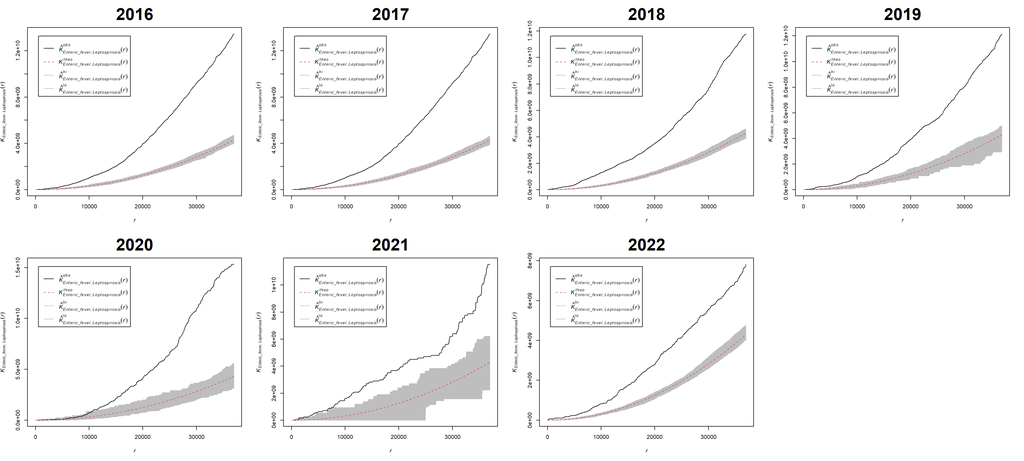

```r
par(mfrow=c(2,4))
plot(env_K16, main = "2016", cex.main = 3)
plot(env_K17, main = "2017", cex.main = 3)
plot(env_K18, main = "2018", cex.main = 3)
plot(env_K19, main = "2019", cex.main = 3)
plot(env_K20, main = "2020", cex.main = 3)
plot(env_K21, main = "2021", cex.main = 3)
plot(env_K22, main = "2022", cex.main = 3)
```